# Week 5: Lab - Word Cloud Chapter Challenge

Victor Arencibia

2/12/2022

# Instructions

Create a word cloud using the `text` column from a real twitter dataset (sample.csv).

```r
# Add your library below.

require(tm)
```

```r
require(wordcloud)
```

# Step 1. Load and Clean the Data

Load in the `sample.csv` dataset from this project’s data folder. Please make sure you transform the document to lowercase, delete stopwords & numbers & punctuation (1 point).

```r
# Write your code below.

#install.packages("readxl")
library(readxl)
sampledf <- read.csv("data/sample.csv", stringsAsFactors = F)

head(sample)
```

```
##
## 1 function (x, size, replace = FALSE, prob = NULL)
## 2 {
## 3     if (length(x) == 1L && is.numeric(x) && is.finite(x) && x >=
## 4         1) {
## 5         if (missing(size))
## 6             size <- x
```

```r
tail(sampledf,20)
```

```
##     tweet_id airline_sentiment airline_sentiment_confidence
## 347 5.69e+17          negative                       0.6596
## 348 5.69e+17          positive                       1.0000
## 349 5.69e+17          negative                       0.6436
## 350 5.69e+17          negative                       0.3617
## 351 5.69e+17          negative                       1.0000
## 352 5.69e+17          negative                       0.7223
## 353 5.69e+17           neutral                       0.6925
## 354 5.69e+17          negative                       1.0000
## 355 5.69e+17          negative                       1.0000
## 356 5.68e+17          negative                       0.6540
## 357 5.68e+17           neutral                       1.0000
## 358 5.68e+17           neutral                       1.0000
## 359 5.68e+17          positive                       1.0000
## 360 5.68e+17          positive                       1.0000
```

[output cut: 111 more lines]

```r
str(sampledf)
```

```
## 'data.frame':    366 obs. of  15 variables:
##  $ tweet_id                    : num  5.7e+17 5.7e+17 5.7e+17 5.7e+17 5.7e+17 ...
##  $ airline_sentiment           : chr  "neutral" "positive" "neutral" "negative" ...
##  $ airline_sentiment_confidence: num  1 0.349 0.684 1 1 ...
##  $ negativereason              : chr  "" "" "" "Bad Flight" ...
##  $ negativereason_confidence   : num  NA 0 NA 0.703 1 ...
##  $ airline                     : chr  "Virgin America" "Virgin America" "Virgin America" "Virgin America" ...
##  $ airline_sentiment_gold      : logi  NA NA NA NA NA NA ...
##  $ name                        : chr  "cairdin" "jnardino" "yvonnalynn" "jnardino" ...
##  $ negativereason_gold         : logi  NA NA NA NA NA NA ...
##  $ retweet_count               : int  0 0 0 0 0 0 0 0 0 0 ...
##  $ text                        : chr  "@VirginAmerica What @dhepburn said." "@VirginAmerica plus you've added commercials to the experience... tacky." "@VirginAmerica I didn't today... Must mean I need to take another trip!" "@VirginAmerica it's really aggressive to blast obnoxious \"entertainmen…
##  $ tweet_coord                 : chr  "" "" "" "" ...
##  $ tweet_created               : chr  "2/24/2015 11:35" "2/24/2015 11:15" "2/24/2015 11:15" "2/24/2015 11:15" ...
##  $ tweet_location              : chr  "" "" "Lets Play" "" ...
##  $ user_timezone               : chr  "Eastern Time (US & Canada)" "Pacific Time (US & Canada)" "Central Time (US & Canada)" "Pacific Time (US & Canada)" ...
```

```r
words.vec <- VectorSource(sampledf)
words.corpus <- Corpus(words.vec)

words.corpus <- tm_map(words.corpus, content_transformer(tolower))
words.corpus <- tm_map(words.corpus, removePunctuation)
words.corpus <- tm_map(words.corpus, removeNumbers)
words.corpus <- tm_map(words.corpus, removeWords, stopwords("english"))
tdm <- TermDocumentMatrix(words.corpus)

str(tdm)
```

```
## List of 6
##  $ i       : int [1:1877] 1 2 3 4 5 6 7 8 9 10 ...
##  $ j       : int [1:1877] 2 2 2 2 4 4 4 4 4 4 ...
##  $ v       : num [1:1877] 1 142 120 103 4 11 25 16 17 4 ...
##  $ nrow    : int 1798
##  $ ncol    : int 15
##  $ dimnames:List of 2
##   ..$ Terms: chr [1:1798] "cneutral" "negative" "neutral" "positive" ...
##   ..$ Docs : chr [1:15] "1" "2" "3" "4" ...
##  - attr(*, "class")= chr [1:2] "TermDocumentMatrix" "simple_triplet_matrix"
##  - attr(*, "weighting")= chr [1:2] "term frequency" "tf"
```

```r
inspect(tdm[1:15,1:15])
```

```
## <<TermDocumentMatrix (terms: 15, documents: 15)>>
## Non-/sparse entries: 26/199
## Sparsity           : 88%
## Maximal term length: 10
## Weighting          : term frequency (tf)
## Sample             :
##            Docs
## Terms       1 11   2 3  4 5 6 7 8 9
##   booking   0  6   0 0 25 0 0 0 0 0
##   cancelled 0 19   0 0 16 0 0 0 0 0
##   cant      0 12   0 0 17 0 0 0 0 0
##   customer  0 11   0 0 45 0 0 0 0 0
##   flight    0 94   0 0 70 0 0 0 0 0
##   issue     0  2   0 0 45 0 0 0 0 0
##   late      0  6   0 0 14 0 0 0 0 0
##   negative  0  0 142 0  0 0 0 0 0 0
##   neutral   0  0 120 0  0 0 0 0 0 0
##   positive  0  1 103 0  0 0 0 0 0 0
```

# Step 2. Adjust the Stopwords

Add “can” and “just” to the stopwords list (1 point).

```r
# Write your code below.
# I had to search google on how to add addition stopwords.

words.corpus <- tm_map(words.corpus, removeWords, c(stopwords("english"),"can", "just"))
```

# Step 3. Adjust the Theme

Use five colors and “Accent” for color theme (1 point).

```r
# Write your code below.

m <- as.matrix(tdm)
wordCounts <- rowSums(m)
wordCounts <- sort(wordCounts, decreasing = TRUE)
head(wordCounts)
```

```
##        virgin       america virginamerica          time        canada
##           374           369           366           243           229
##        flight
##           164
```

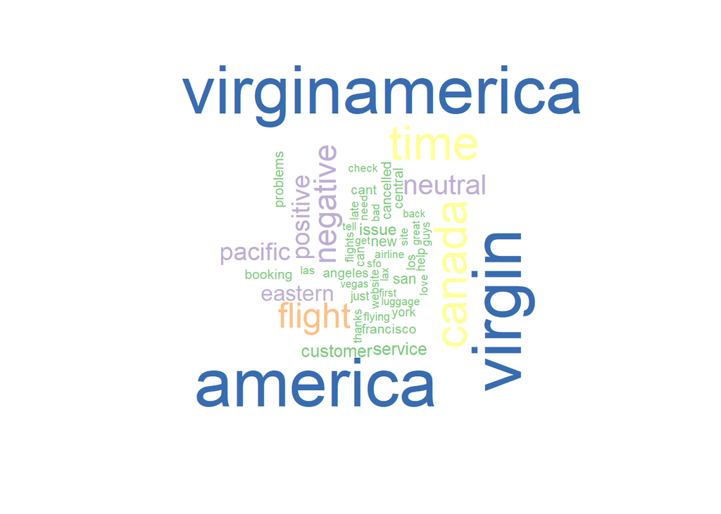

```r
cloudFrame<- data.frame(word=names(wordCounts), freq=wordCounts)
library(RColorBrewer)
wordcloud(names(wordCounts), wordCounts, min.freq=2, max.words=50, rot.per=0.35,
          colors=brewer.pal(5, "Accent"))
```

# Step 4. Analysis

Does the word cloud convey the key points of the document? (1 point).

> I read through parts of the sample exel document and although I couldnt pinpoint exactly how many of each word there was there was definitely a theme. Considering its a post regarding Virgin America’s reviews it doesnt surprise me that the most popular words were America, Virgin America, and time. The word cloud is an impressive visualization tool we as data scientist & engineers could use once we are producing for a company. It allows the viewing to immediatly see what the most common words are, if Negative is in giant letters accross the screen than we know it’s something the orignization would have to address. Especially if we are using a file with thousands of variables and words.

# Step 5. Compile

Submit the compiled file. The wordcloud may prevent you from compiling. If so, do the following:

```
jpeg('p1.jpg')
wordcloud(cloudFrame.t$word, cloudFrame.t$freq)
dev.off()
```

This will make the graphs save in the current working directory.

```r
# Write your code below, if necessary.
#jpeg('p1.jpg')
#wordcloud(names(wordCounts), wordCounts, min.freq=2, max.words=50, rot.per=0.35,
          #colors=brewer.pal(5, "Accent"))
#dev.off()
```